# (Visualizing and Analysing the Data Set of Ford Gobike System Data)

### Percentage of Bike Rides by Gender:

```python
ride_gender_df = df_clean.groupby('member_gender').agg({'bike_id':'count'})
```

```python
ride_gender_df['percentage'] = (ride_gender_df['bike_id']/ride_gender_df['bike_id'].sum())*100
```

[output not shown]

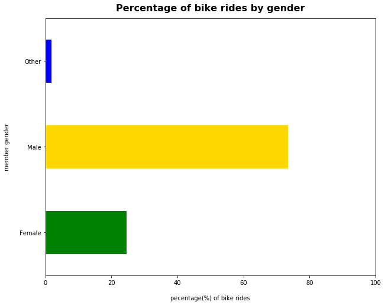

```python
new_color = ['green', 'gold', 'blue']
ride_gender_df['percentage'].plot(kind='barh', color=new_color, figsize=(10,8))
plt.title('Percentage of bike rides by gender', fontsize=16, y=1.015,fontweight='semibold')
plt.ylabel('member gender', labelpad=16)
plt.xlabel('pecentage(%) of bike rides', labelpad=16)
plt.xticks(rotation=360)
plt.xlim(0,100)
```

### Discuss the distribution(s) of your variable(s) of interest. Were there any unusual points? Did you need to perform any transformations?

Most of the people take rides during Weekdays from Monday to Friday may be commute purposes compare to weekends. 8-9 am and 5-6pm are busy hours for daily bike riders.

### Bi-Variate Exploration:

- In this section, I will explore into user type data analysis

```python
# calculating % split for the user type
customer = df_clean.query('user_type == "Customer"')['bike_id'].count()
subscriber = df_clean.query('user_type == "Subscriber"')['bike_id'].count()

customer_prop = customer / df_clean['bike_id'].count()
subscriber_prop = subscriber / df_clean['bike_id'].count()
```

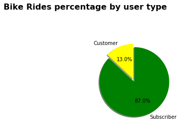

```python
plt.subplot(1, 2, 2)

labels = ['Customer', 'Subscriber']
sizes = [customer_prop, subscriber_prop]
colors = ['yellow', 'green']
explode = (0, 0.1)

plt.pie(sizes, explode=explode, labels=labels, colors = colors,
        autopct='%1.1f%%', shadow=True, startangle=90)
plt.axis('equal')

plt.suptitle('Bike Rides percentage by user type', y=1.03, fontsize=16, fontweight='semibold');
```

87% of Subscribers are using bike service compare to customers using bike service with 13%. This tell us that Subscribers often use it for daily commute and customers use it for more lesiure activities

### weekly usage Trends by user type:

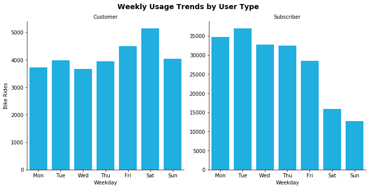

```python
weekday = ['Mon', 'Tue', 'Wed', 'Thu', 'Fri', 'Sat', 'Sun']
g = sns.catplot(data=df_clean, x='st_weekday', col="user_type", kind='count', sharey = False,
            color = 'deepskyblue', order = weekday)
g.set_axis_labels("Weekday", "Bike Rides")
g.set_titles("{col_name}")
g.fig.suptitle('Weekly Usage Trends by User Type', y=1.03, fontsize=14, fontweight='semibold');
```

From above bar graph trends shows difference between customers and subscribers.Customers often use the service during weekends where as Subscribers mostly use the service during regular weekdays from Monday to Friday, this tell us that subscribers are regularly use it for work and home commute purposes and customers use it for recreational activities during weekends.

### Hourly usage trends by User type:

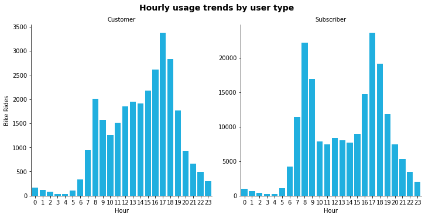

```python
g = sns.catplot(data=df_clean, x='st_hour', col="user_type", kind='count', sharey = False,
            color = 'deepskyblue')
g.set_axis_labels("Hour", "Bike Rides")
g.set_titles("{col_name}")
g.fig.suptitle('Hourly usage trends by user type', y=1.03, fontsize=14, fontweight='semibold');
```

```python
# Compute minutes for trip duration from duration_sec column
df_clean['duration_min'] = df_clean['duration_sec']/60
```

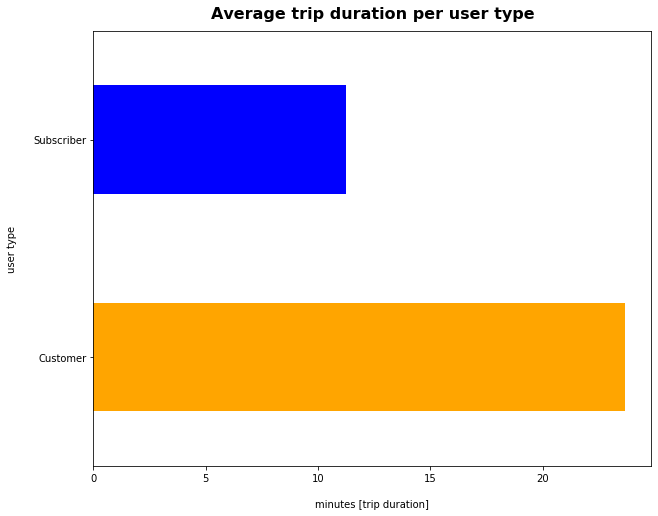

```python
new_color=['orange', 'blue']
ax = df_clean.groupby('user_type')['duration_min'].mean().plot(kind='barh', color=new_color, figsize=(10,8))
ax.set_title('Average trip duration per user type', fontsize=16, y=1.015,fontweight='semibold')
ax.set_ylabel('user type', labelpad=16)
ax.set_xlabel('minutes [trip duration]', labelpad=16)
```

### Average Bike Trip distance of subscribers vs customers:

```python
#Calculate distance in miles
def distance(origin, destination):
    """
    Parameters
    origin : tuple of float
        (lat, long)
    destination : tuple of float
        (lat, long)

    Returns
    distance_in_km : float
    """
    lat1, lon1 = origin
    lat2, lon2 = destination
    radius = 6371  # km

    dlat = math.radians(lat2 - lat1)
    dlon = math.radians(lon2 - lon1)
    a = (math.sin(dlat / 2) * math.sin(dlat / 2) +
         math.cos(math.radians(lat1)) * math.cos(math.radians(lat2)) *
         math.sin(dlon / 2) * math.sin(dlon / 2))
    c = 2 * math.atan2(math.sqrt(a), math.sqrt(1 - a))
    d = radius * c

    return d
```

```python
# Convert Kms to Miles
df_clean['distance_kms'] = df_clean.apply(lambda x: distance((x['start_station_latitude'], x['start_station_longitude']), (x['end_station_latitude'], x['end_station_longitude'])), axis=1)
df_clean['distance_miles'] = df_clean['distance_kms']*0.621371
```

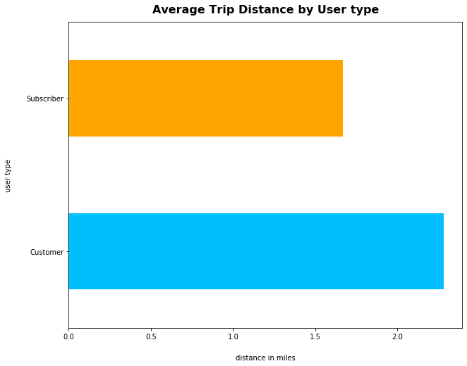

```python
new_color= ['deepskyblue','orange']
ax = df_clean.groupby('user_type')['distance_miles'].mean().plot(kind='barh', color=new_color, figsize=(10,8))
ax.set_title('Average Trip Distance by User type', fontsize=16, y=1.015,fontweight='semibold')
ax.set_ylabel('user type', labelpad=20)
ax.set_xlabel('distance in miles', labelpad=20)
```

### Talk about some of the relationships you observed in this part of the investigation. How did the feature(s) of interest vary with other features in the dataset?

There is an interesting differences between Customers and Subscribers behavior patterns. As mentioned in above Bi-variate Exploration Analysis, Customers are more causual riders who often use the service between 10 am -7pm and slowly increase from mid of the week and take more rides during weekends. Subscribers who actually uses the service from Monday -Friday between 8 am-9am and 5pm-6pm.

### Multi-Variate Exploration:

### Bike Rides by Gender:

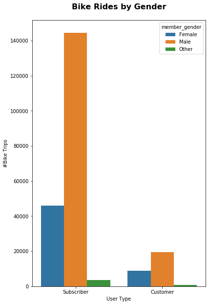

```python
plt.figure(figsize = [14, 10])

# code for the bar chart
plt.subplot(1, 2, 1)

g = sns.countplot(data=df_clean, x="user_type", hue="member_gender", order=df_clean.user_type.value_counts().index)
g.set_xlabel('User Type')
g.set_ylabel('#Bike Trips')
g.set_title('Bike Rides by Gender', y=1.03, fontsize=16, fontweight='semibold');
```

Above Bar graph shows that Most of the Males and Females utilizing more service or trips compare to Customer user type. However it looks like from both user types males are using service than females.

### Subscribers Bike Trends by Age Gender,Weekdays, Hours Analysis:

```python
# Extract Subscribers age groups between 20 and 60
subscriber_df01 = df_clean[(df_clean['member_age']>=20) & (df_clean['member_age']<60)
                              &(df_clean['st_hour']>5)&(df_clean['user_type']=='Subscriber')
                             ].groupby(['st_weekday', 'st_hour']).agg({'bike_id' : 'count'}).rename(columns={'bike_id':'count'}).reset_index()
```

```python
#Extract Subscribers age groups between 20 and 30
subscriber_df2 = df_clean[(df_clean['member_age']>=20) & (df_clean['member_age']<30)
                              &(df_clean['st_hour']>5)&(df_clean['user_type']=='Subscriber')
                             ].groupby(['st_weekday', 'st_hour']).agg({'bike_id' : 'count'}).rename(columns={'bike_id':'count'}).reset_index()
```

```python
subscriber_df2['count'].head()
```

```
0    170
1    459
2    910
3    800
4    376
Name: count, dtype: int64
```

```python
# Extract Subscribers age groups between 30 and 40
subscriber_df3 = df_clean[(df_clean['member_age']>=30) & (df_clean['member_age']<40)
                              &(df_clean['st_hour']>5)&(df_clean['user_type']=='Subscriber')
                             ].groupby(['st_weekday', 'st_hour']).agg({'bike_id' : 'count'}).rename(columns={'bike_id':'count'}).reset_index()
```

```python
# Extract Subscribers age groups between 40 and 50
subscriber_df4 = df_clean[(df_clean['member_age']>=40) & (df_clean['member_age']<50)
                              &(df_clean['st_hour']>5)&(df_clean['user_type']=='Subscriber')
                             ].groupby(['st_weekday', 'st_hour']).agg({'bike_id' : 'count'}).rename(columns={'bike_id':'count'}).reset_index()
```

```python
# Extract Weekdays for age groups between 20 and 30
subscriber_df2['st_weekday'] = pd.Categorical(subscriber_df2['st_weekday'], categories=['Mon','Tue','Wed','Thu','Fri','Sat', 'Sun'], ordered=True)
```

```python
# Extract Weekdays for age groups between 30 and 40
subscriber_df3['st_weekday'] = pd.Categorical(subscriber_df3['st_weekday'], categories=['Mon','Tue','Wed','Thu','Fri','Sat', 'Sun'], ordered=True)
```

```python
# Extract Weekdays for age groups between 40 and 50
subscriber_df4['st_weekday'] = pd.Categorical(subscriber_df4['st_weekday'], categories=['Mon','Tue','Wed','Thu','Fri','Sat', 'Sun'], ordered=True)
```

```python
# Calculate Percentage for 20 to 30 age groups
subscriber_df2['count_percentage'] = subscriber_df2['count'].apply(lambda x: (x/subscriber_df01['count'].sum())*100)
```

```python
# Calculate Percentage for 30 to 40 age groups
subscriber_df3['count_percentage'] = subscriber_df3['count'].apply(lambda x: (x/subscriber_df01['count'].sum())*100)
```

```python
# Calculate Percentage for 40 to 50 age groups
subscriber_df4['count_percentage'] = subscriber_df4['count'].apply(lambda x: (x/subscriber_df01['count'].sum())*100)
```

```python
# Calculate Rank in ascending order for 20 to 30 age groups
subscriber_df2['rank'] = subscriber_df2['count_percentage'].rank(ascending=False).astype(int)
```

```python
# Calculate Rank in ascending order for 30 to 40 age groups
subscriber_df3['rank'] = subscriber_df3['count_percentage'].rank(ascending=False).astype(int)
```

```python
# Calculate Rank in ascending order for 40 to 50 age groups
subscriber_df4['rank'] = subscriber_df4['count_percentage'].rank(ascending=False).astype(int)
```

```python
# Create Pivot table for 20 to 30 age groups
subscriber_pivot02 = subscriber_df2.pivot_table(index='st_hour', columns='st_weekday', values='rank')
```

```python
# Create Pivot table for 30 to 40 age groups
subscriber_pivot03 = subscriber_df3.pivot_table(index='st_hour', columns='st_weekday', values='rank')
```

```python
# Create Pivot table for 40 to 50 age groups
subscriber_pivot04 = subscriber_df4.pivot_table(index='st_hour', columns='st_weekday', values='rank')
```

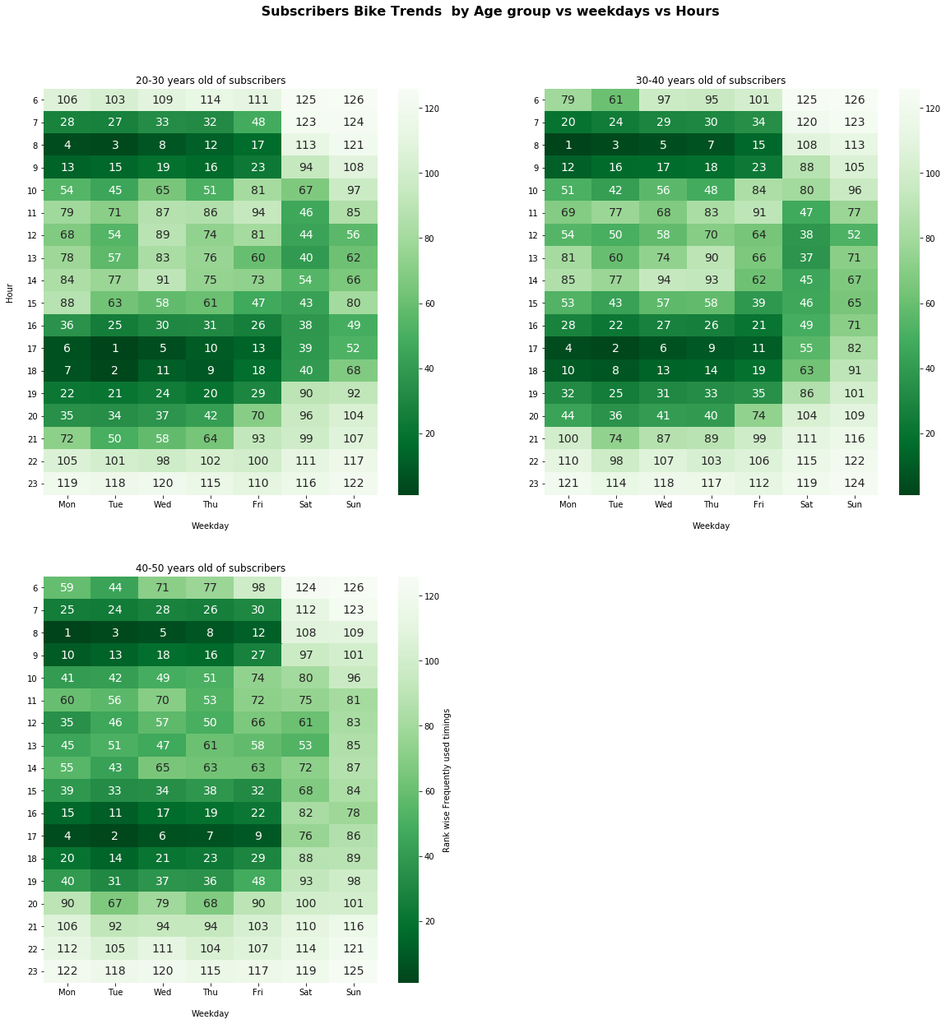

```python
plt.figure(figsize=(20,20))
plt.subplot(221)
plt.suptitle(' Subscribers Bike Trends  by Age group vs weekdays vs Hours', fontsize=16,fontweight='semibold', y=0.95)
sns.heatmap(subscriber_pivot02, fmt='d', annot=True, cmap='Greens_r', annot_kws={"size": 14})
plt.title("20-30 years old of subscribers", y=1.015)
plt.xlabel('Weekday', labelpad=16)
plt.ylabel('Hour', labelpad=16)
plt.yticks(rotation=360)
plt.subplot(222)
sns.heatmap(subscriber_pivot03, fmt='d', annot=True, cmap='Greens_r', annot_kws={"size": 14})
plt.title("30-40 years old of subscribers", y=1.015)
plt.xlabel('Weekday', labelpad=16)
plt.ylabel(' ')
plt.yticks(rotation=360)
plt.subplot(223)
sns.heatmap(subscriber_pivot04, fmt='d', annot=True, cmap='Greens_r', annot_kws={"size": 14}, cbar_kws={'label': 'Rank wise Frequently used timings'})
plt.title("40-50 years old of subscribers", y=1.015)
plt.xlabel('Weekday', labelpad=16)
plt.ylabel(' ')
plt.yticks(rotation=360)
```

### Conclusion:

87% of Subscribers are using bike service compare to customers using bike service with 13%.People use this service on weekdays more than weekends. 8am and 5pm are the peak hours for this service. Also, people use this service when they are in lunch time as well.Customers' rides seems increasing slightly but subscibers' rides reached 6 times more than customers'.

From both user types: Subscriers and Customers Men took more rides compare to Female riders. In which 20-40 age group people who used most of the service compare to all other age groups.